# Analysis LEZ 2

41783

25/02/2020

Basic configuration and loading of packages:

```r
# library(jsonlite)
library(tidyverse)
library(rvest)

library(sf) # Geo analysis
# library("rgdal")

library(DBI) # SQL db

library(panelView)
library(lubridate)
```

## Index of contents

- Read data from pre-processing
  - Nuts regions geographies
  - data from capstone_db
    - nuts_time (outcomes, controls and mediators)
    - treatment from Umweltzonen
- Do explorative analysis on the volatility of outcomes
- Create variables of interest
- Do analysis

## Read data from pre-processing:

### Nuts Regions geographies

```r
# Characteristics of nuts3:

nuts.sf <- readRDS("data/nuts_sf_treated")

nuts.sf <- nuts.sf %>%
  dplyr::rename(
    geo = NUTS_ID,
    nuts_level = LEVL_CODE,
    country = CNTR_CODE,
    nuts_name = NUTS_NAME
  )

nuts.sf %>% as.data.frame() %>% head()
```

|  | nuts_level | geo | country | nuts_name | geometry | with_uar_point | with_uar_30km | with_uar_60km | with_gzones_point | with_gzones_30km | with_gzones_60km | with_umweltzonen_point | with_umweltzonen_30km | with_umweltzonen_60km | treated_osm | treated_uar | treated_gz | treated_uz | treated_any | contr_restr_point | contr_restr_30km | contr_restr_60km | urb_index | State | LEZ | simple_LEZ | Status | Stage_1 | Stage_2 | … |
| --- | --- | --- | --- | --- | --- | --- | --- | --- | --- | --- | --- | --- | --- | --- | --- | --- | --- | --- | --- | --- | --- | --- | --- | --- | --- | --- | --- | --- | --- | --- |
| 1 | 3 | HR043 | HR | Krapinsko-zagorska županija |  | FALSE | FALSE | FALSE | FALSE | FALSE | FALSE | FALSE | FALSE | FALSE | FALSE | FALSE | FALSE | FALSE | FALSE | TRUE | TRUE | TRUE | 2.884615 | NA | NA | NA | NA | NA | NA | … |
| 2 | 2 | CH02 | CH | Espace Mittelland |  | TRUE | TRUE | TRUE | FALSE | FALSE | TRUE | FALSE | FALSE | TRUE | FALSE | FALSE | FALSE | FALSE | FALSE | FALSE | FALSE | FALSE | 2.661166 | NA | NA | NA | NA | NA | NA | … |
| 3 | 2 | CH03 | CH | Nordwestschweiz |  | FALSE | TRUE | TRUE | FALSE | FALSE | TRUE | FALSE | FALSE | TRUE | FALSE | FALSE | FALSE | FALSE | FALSE | TRUE | FALSE | FALSE | 2.313433 | NA | NA | NA | NA | NA | NA | … |
| 4 | 2 | AL02 | AL | Qender |  | FALSE | FALSE | FALSE | FALSE | FALSE | FALSE | FALSE | FALSE | FALSE | FALSE | FALSE | FALSE | FALSE | FALSE | TRUE | TRUE | TRUE | 2.333333 | NA | NA | NA | NA | NA | NA | … |
| 5 | 2 | AL03 | AL | Jug |  | FALSE | FALSE | FALSE | FALSE | FALSE | FALSE | FALSE | FALSE | FALSE | FALSE | FALSE | FALSE | FALSE | FALSE | TRUE | TRUE | TRUE | 2.800000 | NA | NA | NA | NA | NA | NA | … |
| 6 | 2 | BG33 | BG |  |  | FALSE | FALSE | FALSE | FALSE | FALSE | FALSE | FALSE | FALSE | FALSE | FALSE | FALSE | FALSE | FALSE | FALSE | TRUE | TRUE | TRUE | 2.972940 | NA | NA | NA | NA | NA | NA | … |

### Get data from SQLdb:

```r
db <- dbConnect(RSQLite::SQLite(), "data/capstonedb")
dbListTables(db)
```

```
[1] "airq_plans"   "nuts3"        "nuts_time"    "umweltezonen"
[5] "umweltzonen"
```

Tables:

- airq_plans: List of (new) air quality plans
- nuts3: NUTS code, name and attainment status according to UAR and GZ, and minimum year for GZ
- umweltzonen: Treatment status of all zones in germany for each status with timing.
- nuts_time statistical data on NUTS regions (outcomes and controls)

#### Get nuts_time (outcomes, mediators and controls)

```r
nuts_time <- dbGetQuery(db, "SELECT * from nuts_time")
nuts_time %>% filter(time == 2006)
```

| geo | time | gdp_mio_eur | gdp_eur_hab | gdp_mio_pps | pop_total | pop_unk_age | pop_15_64 | pop_65plus | pop_less15 | empl_O-Q | empl_J | empl_A | empl_M_N | empl_L | empl_K | empl_F | empl_B-E | empl_O-U | empl_G-I | empl_G-J | empl_TOTAL | empl_K-N | empl_C | empl_R-U | gva_F | gva_J | gva_G_J | gva_M_N | gva_R_U | … |
| --- | --- | --- | --- | --- | --- | --- | --- | --- | --- | --- | --- | --- | --- | --- | --- | --- | --- | --- | --- | --- | --- | --- | --- | --- | --- | --- | --- | --- | --- | --- |
| AL | 2006 | 7091.00 | 2400 | 16247.00 | 3003329 | 0 | 1948463 | 275052 | 779814 | NA | NA | NA | NA | NA | NA | NA | NA | NA | NA | NA | NA | NA | NA | NA | NA | NA | NA | NA | NA | … |
| AL0 | 2006 | NA | NA | NA | 3003329 | 0 | 1948463 | 275052 | 779814 | NA | NA | NA | NA | NA | NA | NA | NA | NA | NA | NA | NA | NA | NA | NA | NA | NA | NA | NA | NA | … |
| AL01 | 2006 | NA | NA | NA | NA | 0 | NA | NA | NA | NA | NA | NA | NA | NA | NA | NA | NA | NA | NA | NA | NA | NA | NA | NA | NA | NA | NA | NA | NA | … |
| AL011 | 2006 | NA | NA | NA | NA | 0 | NA | NA | NA | NA | NA | NA | NA | NA | NA | NA | NA | NA | NA | NA | NA | NA | NA | NA | NA | NA | NA | NA | NA | … |
| AL012 | 2006 | NA | NA | NA | NA | 0 | NA | NA | NA | NA | NA | NA | NA | NA | NA | NA | NA | NA | NA | NA | NA | NA | NA | NA | NA | NA | NA | NA | NA | … |
| AL013 | 2006 | NA | NA | NA | NA | 0 | NA | NA | NA | NA | NA | NA | NA | NA | NA | NA | NA | NA | NA | NA | NA | NA | NA | NA | NA | NA | NA | NA | NA | … |
| AL014 | 2006 | NA | NA | NA | NA | 0 | NA | NA | NA | NA | NA | NA | NA | NA | NA | NA | NA | NA | NA | NA | NA | NA | NA | NA | NA | NA | NA | NA | NA | … |
| AL015 | 2006 | NA | NA | NA | NA | 0 | NA | NA | NA | NA | NA | NA | NA | NA | NA | NA | NA | NA | NA | NA | NA | NA | NA | NA | NA | NA | NA | NA | NA | … |
| AL02 | 2006 | NA | NA | NA | NA | 0 | NA | NA | NA | NA | NA | NA | NA | NA | NA | NA | NA | NA | NA | NA | NA | NA | NA | NA | NA | NA | NA | NA | NA | … |
| AL021 | 2006 | NA | NA | NA | NA | 0 | NA | NA | NA | NA | NA | NA | NA | NA | NA | NA | NA | NA | NA | NA | NA | NA | NA | NA | NA | NA | NA | NA | NA | … |

[output cut: 990 more lines]

```r
nuts_time %>% names()
```

```
  [1] "geo"               "time"
  [3] "gdp_mio_eur"       "gdp_eur_hab"
  [5] "gdp_mio_pps"       "pop_total"
  [7] "pop_unk_age"       "pop_15_64"
  [9] "pop_65plus"        "pop_less15"
 [11] "empl_O-Q"          "empl_J"
 [13] "empl_A"            "empl_M_N"
 [15] "empl_L"            "empl_K"
 [17] "empl_F"            "empl_B-E"
 [19] "empl_O-U"          "empl_G-I"
 [21] "empl_G-J"          "empl_TOTAL"
 [23] "empl_K-N"          "empl_C"
 [25] "empl_R-U"          "gva_F"
 [27] "gva_J"             "gva_G_J"
 [29] "gva_M_N"           "gva_R_U"
```

[output cut: 55 more lines]

```r
nuts_time %>%
  filter(geo == "PL91") %>%
  select(time)
```

| time |
| --- |
| 2000 |
| 2001 |
| 2002 |
| 2003 |
| 2004 |
| 2005 |
| 2006 |
| 2007 |
| 2008 |
| 2009 |

[output cut: 10 more lines]

Create variables of interest (outcomes and controls) (and possibly a restricted dataset only with those)

| geo | time | gva_rate_work | gva_tot | gva_rate_public |
| --- | --- | --- | --- | --- |
| DE | 1990 | NA | NA | NA |
| DE | 1991 | NA | NA | NA |
| DE | 1992 | NA | NA | NA |
| DE | 1993 | NA | NA | NA |
| DE | 1994 | NA | NA | NA |
| DE | 1995 | NA | NA | NA |
| DE | 1996 | NA | NA | NA |
| DE | 1997 | NA | NA | NA |
| DE | 1998 | NA | NA | NA |
| DE | 1999 | NA | NA | NA |

[output cut: 990 more lines]

### Small analysis of the volatility of data:

```r
get_volatility <- function(data = nuts_time,
                           CNTR_CODE = "DE",
                           time_vector = 2000:2019,
                           variable = "gdp_eur_hab",
                           cluster_differences = "nuts1" # can be "country"
){
  temp <- data %>%
    arrange(geo, time) %>%
    dplyr::mutate(nuts1 = substr(geo, 3, 4),
           country = substr(geo, 1, 2)) %>%
    filter(
      country == CNTR_CODE,
      # !is.element(time, c(2008, 2009, 2010, 2011)),
    ) %>%
    dplyr::group_by(geo) %>%
    dplyr::mutate(perc_change_unit = (eval(parse(text=variable))-lag(eval(parse(text=variable))))/lag(eval(parse(text=variable)))*100) %>%
    ungroup() %>%
    dplyr::group_by("nuts1", time) %>%
    dplyr::mutate(mean_change_group = mean(perc_change_unit, na.rm = TRUE),
           perc_change_dev = perc_change_unit - mean_change_group) %>%
    ungroup() %>%
    select(geo, time, variable, mean_change_group, perc_change_unit, perc_change_dev)
  print(temp %>% summary)
  return(temp)
}
```

```r
temp2 <- get_volatility(data = nuts_time, CNTR_CODE = "DE",
                       time_vector = 2000:2019,
                       variable = "unempR_T")
```

```
     geo                 time         unempR_T
 Length:10485       Min.   :1990   Min.   : 1.80
 Class :character   1st Qu.:2002   1st Qu.: 4.40
 Mode  :character   Median :2008   Median : 6.30
                    Mean   :2008   Mean   : 7.41
                    3rd Qu.:2014   3rd Qu.: 8.80
                    Max.   :2019   Max.   :22.40
                                   NA's   :9456
 mean_change_group perc_change_unit  perc_change_dev
 Min.   :-16.518   Min.   :-34.146   Min.   :-26.906
 1st Qu.: -9.624   1st Qu.:-12.116   1st Qu.: -5.186
 Median : -7.240   Median : -5.941   Median : -0.247
 Mean   : -3.467   Mean   : -3.652   Mean   :  0.000
 3rd Qu.:  4.749   3rd Qu.:  3.643   3rd Qu.:  4.350
 Max.   : 17.938   Max.   : 47.059   Max.   : 38.846
 NA's   :2209      NA's   :9511      NA's   :9511
```

```r
# temp2

# pop_total, empl_EMP_TOTAL, inv_TOTAL, wages_TOTAL, mean_pol,
```

### Nuts Regions geographies and treatment status

All nuts 3 and nuts 2 regions that had multiple LEZ were excluded from this data, so will have NA when I merge it with “dta”.

```r
nuts_treated <- readRDS("data/nuts_sf_treated")

nuts_treated <- nuts_treated %>%
  dplyr::rename(
    geo = NUTS_ID,
    nuts_level = LEVL_CODE,
    country = CNTR_CODE,
    nuts_name = NUTS_NAME
  )

nuts_treated %>% as.data.frame() %>% head()
```

|  | nuts_level | geo | country | nuts_name | geometry | with_uar_point | with_uar_30km | with_uar_60km | with_gzones_point | with_gzones_30km | with_gzones_60km | with_umweltzonen_point | with_umweltzonen_30km | with_umweltzonen_60km | treated_osm | treated_uar | treated_gz | treated_uz | treated_any | contr_restr_point | contr_restr_30km | contr_restr_60km | urb_index | State | LEZ | simple_LEZ | Status | Stage_1 | Stage_2 | … |
| --- | --- | --- | --- | --- | --- | --- | --- | --- | --- | --- | --- | --- | --- | --- | --- | --- | --- | --- | --- | --- | --- | --- | --- | --- | --- | --- | --- | --- | --- | --- |
| 1 | 3 | HR043 | HR | Krapinsko-zagorska županija |  | FALSE | FALSE | FALSE | FALSE | FALSE | FALSE | FALSE | FALSE | FALSE | FALSE | FALSE | FALSE | FALSE | FALSE | TRUE | TRUE | TRUE | 2.884615 | NA | NA | NA | NA | NA | NA | … |
| 2 | 2 | CH02 | CH | Espace Mittelland |  | TRUE | TRUE | TRUE | FALSE | FALSE | TRUE | FALSE | FALSE | TRUE | FALSE | FALSE | FALSE | FALSE | FALSE | FALSE | FALSE | FALSE | 2.661166 | NA | NA | NA | NA | NA | NA | … |
| 3 | 2 | CH03 | CH | Nordwestschweiz |  | FALSE | TRUE | TRUE | FALSE | FALSE | TRUE | FALSE | FALSE | TRUE | FALSE | FALSE | FALSE | FALSE | FALSE | TRUE | FALSE | FALSE | 2.313433 | NA | NA | NA | NA | NA | NA | … |
| 4 | 2 | AL02 | AL | Qender |  | FALSE | FALSE | FALSE | FALSE | FALSE | FALSE | FALSE | FALSE | FALSE | FALSE | FALSE | FALSE | FALSE | FALSE | TRUE | TRUE | TRUE | 2.333333 | NA | NA | NA | NA | NA | NA | … |
| 5 | 2 | AL03 | AL | Jug |  | FALSE | FALSE | FALSE | FALSE | FALSE | FALSE | FALSE | FALSE | FALSE | FALSE | FALSE | FALSE | FALSE | FALSE | TRUE | TRUE | TRUE | 2.800000 | NA | NA | NA | NA | NA | NA | … |
| 6 | 2 | BG33 | BG |  |  | FALSE | FALSE | FALSE | FALSE | FALSE | FALSE | FALSE | FALSE | FALSE | FALSE | FALSE | FALSE | FALSE | FALSE | TRUE | TRUE | TRUE | 2.972940 | NA | NA | NA | NA | NA | NA | … |

## Unite variables and treatment status:

```r
main_dta <- nuts_treated %>%
  as.data.frame() %>%
  select(-geometry) %>%
  right_join(nuts_time, by = "geo")

main_dta %>% names()
```

```
  [1] "nuts_level"              "geo"
  [3] "country"                 "nuts_name"
  [5] "with_uar_point"          "with_uar_30km"
  [7] "with_uar_60km"           "with_gzones_point"
  [9] "with_gzones_30km"        "with_gzones_60km"
 [11] "with_umweltzonen_point"  "with_umweltzonen_30km"
 [13] "with_umweltzonen_60km"   "treated_osm"
 [15] "treated_uar"             "treated_gz"
 [17] "treated_uz"              "treated_any"
 [19] "contr_restr_point"       "contr_restr_30km"
 [21] "contr_restr_60km"        "urb_index"
 [23] "State"                   "LEZ"
 [25] "simple_LEZ"              "Status"
 [27] "Stage_1"                 "Stage_2"
 [29] "Stage_3"                 "Announcment"
```

[output cut: 84 more lines]

```r
main_dta %>% head()
```

|  | nuts_level | geo | country | nuts_name | with_uar_point | with_uar_30km | with_uar_60km | with_gzones_point | with_gzones_30km | with_gzones_60km | with_umweltzonen_point | with_umweltzonen_30km | with_umweltzonen_60km | treated_osm | treated_uar | treated_gz | treated_uz | treated_any | contr_restr_point | contr_restr_30km | contr_restr_60km | urb_index | State | LEZ | simple_LEZ | Status | Stage_1 | Stage_2 | Stage_3 | … |
| --- | --- | --- | --- | --- | --- | --- | --- | --- | --- | --- | --- | --- | --- | --- | --- | --- | --- | --- | --- | --- | --- | --- | --- | --- | --- | --- | --- | --- | --- | --- |
| 1 | 3 | HR043 | HR | Krapinsko-zagorska županija | FALSE | FALSE | FALSE | FALSE | FALSE | FALSE | FALSE | FALSE | FALSE | FALSE | FALSE | FALSE | FALSE | FALSE | TRUE | TRUE | TRUE | 2.884615 | NA | NA | NA | NA | NA | NA | NA | … |
| 2 | 3 | HR043 | HR | Krapinsko-zagorska županija | FALSE | FALSE | FALSE | FALSE | FALSE | FALSE | FALSE | FALSE | FALSE | FALSE | FALSE | FALSE | FALSE | FALSE | TRUE | TRUE | TRUE | 2.884615 | NA | NA | NA | NA | NA | NA | NA | … |
| 3 | 3 | HR043 | HR | Krapinsko-zagorska županija | FALSE | FALSE | FALSE | FALSE | FALSE | FALSE | FALSE | FALSE | FALSE | FALSE | FALSE | FALSE | FALSE | FALSE | TRUE | TRUE | TRUE | 2.884615 | NA | NA | NA | NA | NA | NA | NA | … |
| 4 | 3 | HR043 | HR | Krapinsko-zagorska županija | FALSE | FALSE | FALSE | FALSE | FALSE | FALSE | FALSE | FALSE | FALSE | FALSE | FALSE | FALSE | FALSE | FALSE | TRUE | TRUE | TRUE | 2.884615 | NA | NA | NA | NA | NA | NA | NA | … |
| 5 | 3 | HR043 | HR | Krapinsko-zagorska županija | FALSE | FALSE | FALSE | FALSE | FALSE | FALSE | FALSE | FALSE | FALSE | FALSE | FALSE | FALSE | FALSE | FALSE | TRUE | TRUE | TRUE | 2.884615 | NA | NA | NA | NA | NA | NA | NA | … |
| 6 | 3 | HR043 | HR | Krapinsko-zagorska županija | FALSE | FALSE | FALSE | FALSE | FALSE | FALSE | FALSE | FALSE | FALSE | FALSE | FALSE | FALSE | FALSE | FALSE | TRUE | TRUE | TRUE | 2.884615 | NA | NA | NA | NA | NA | NA | NA | … |

```r
# saveRDS(main_dta, "data/main_dta.rds")
```

### Searcher for NA values:

```
[1] "The country CH has no obs"
[1] "The country CY has no obs"
[1] "The country NA has no obs"
```

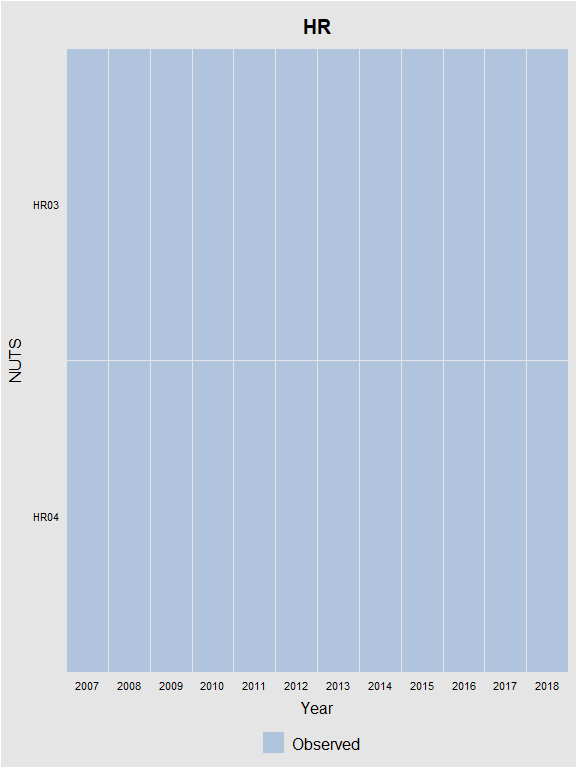

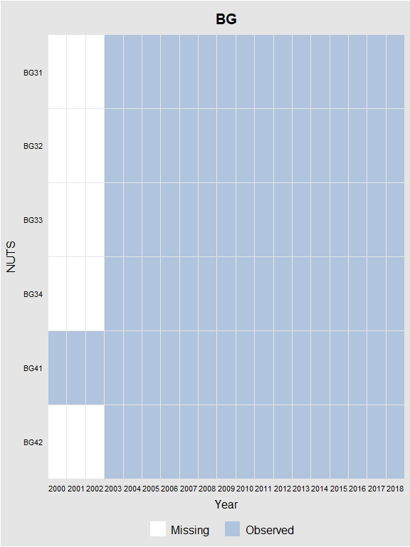

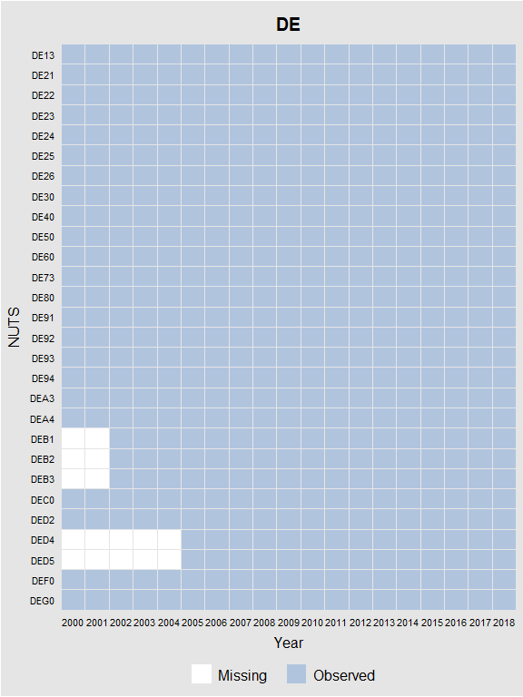

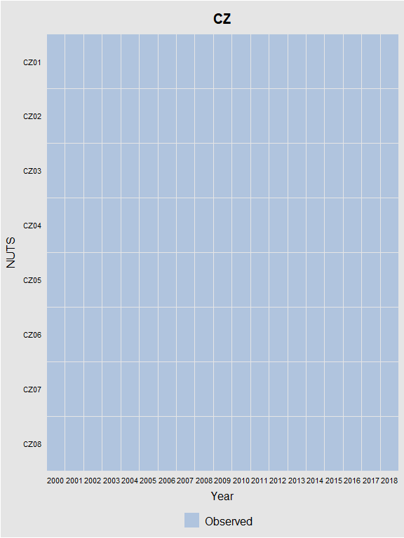

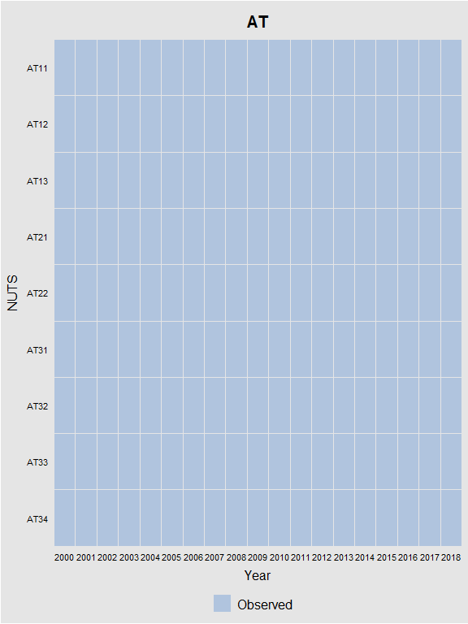

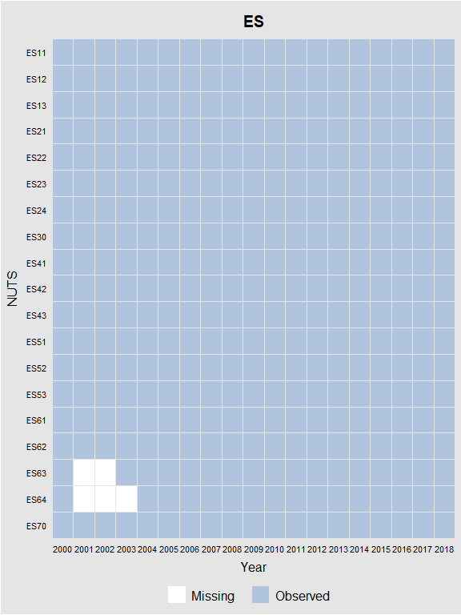

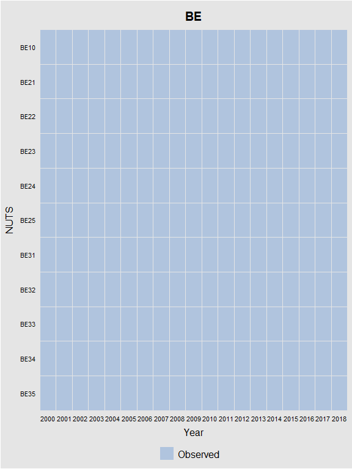

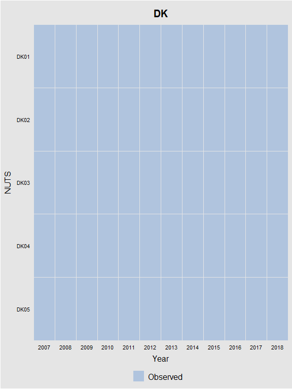

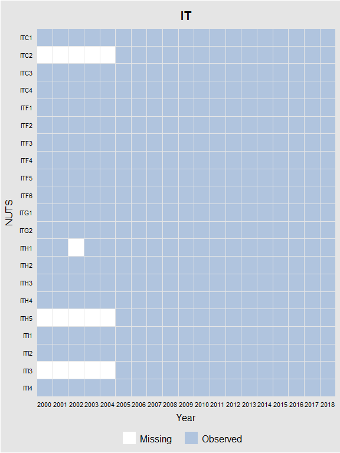

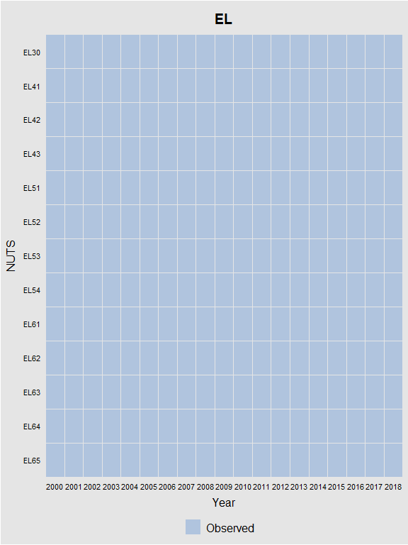

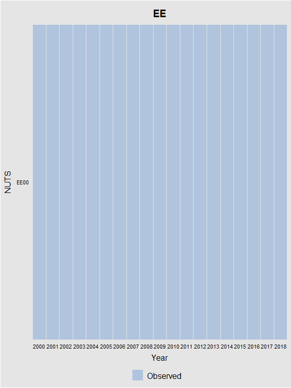

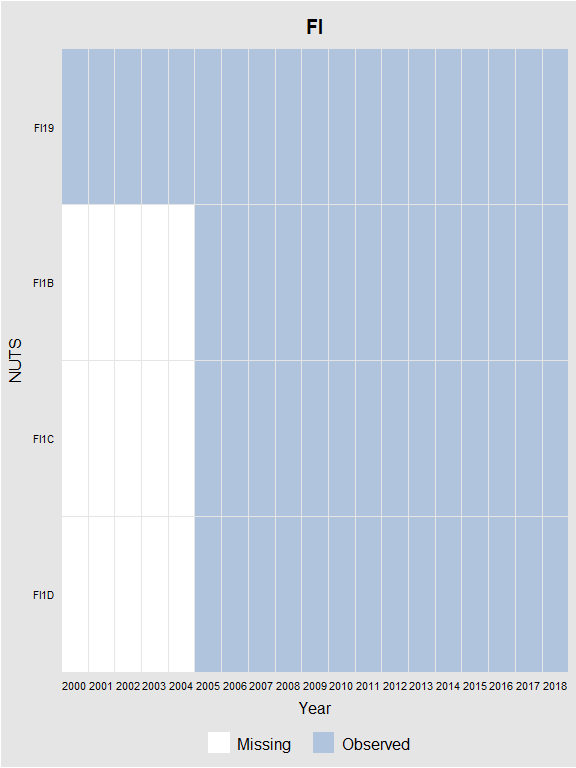

[20 more figures not shown]

```r
countries <- main_dta$country %>% unique()
countries <- countries[-c(3, 23, 34)]

# i <- 1
for (c in countries[1:length(countries)]){
  # print(i)
  # i <- i+1
  temp <- main_dta %>%
    filter(country == c)

  sum_na <- temp %>%
  dplyr::select(unempR_T, urb_index, gdp_eur_hab) %>%
  is.na() %>% colSums() %>% max()
  if(sum_na == nrow(temp)){
    print(paste0("The country ", c, " has no obs"))
    next
  }

  panelView(1 ~ unempR_T + urb_index + gdp_eur_hab,
          data = temp,
          index = c("geo","time"),
          ignore.treat = TRUE,
          xlab = "Year",
          ylab = "NUTS",
          by.timing = TRUE,
          main = c
          # axis.lab.gap = c(0,60)
          # show.id = c(1:25), # number id of ones to show
          )
}
```

# Synthetic control method:

Manual: https://cran.r-project.org/web/packages/Synth/Synth.pdf

More info:

http://www.mit.edu/~jhainm/fqa.htm

http://yiqingxu.org/teaching/17802/synth.pdf

https://www.stata.com/meeting/uk17/slides/uk17_Cerulli.pdf

https://blogs.worldbank.org/impactevaluations/evaluating-regulatory-reforms-using-the-synthetic-control-method https://jech.bmj.com/content/72/8/673

Possibly then complement by ### **Fast and reliable computation of generalized synthetic controls (MSCMT package)** (look at Mendelay paper and to https://cran.r-project.org/web/packages/MSCMT/index.html)

## MASC

> See "Implementation ECI borrador

# Generalized Synthetic control method (experiment)

- Unrestricted weights (can be negative or positive)
- Calculation of ATE
- Calculation of Matrix completion methods.
1. Try with NUTS 2 regions.
- Variable: Unemployment rate total, case: Berlin
2. Try with NUTS 3 regions.
- Variable: Employed population rate, case: Aachen

```r
library(gsynth)
library(lubridate)

# Transformate treatment var into a dummy variable
# (Would be good to do this before.)

main_dta <- main_dta %>%
  mutate(
    is_inagurated = case_when(
      is.na(year_stage1) ~ 0, # If its control, never inagurated
      time < year_stage1 ~ 0, # If its before the inaguration
      TRUE ~ 1 # if neither, then its after
    ),
    # create a placebo treatment
    is_inagurated_3y = case_when(
      is.na(year_stage1) ~ 0, # If its control, never inagurated
      time < year_stage1 - 3 ~ 0, # If its more than 3 years beforethe inaguration
      TRUE ~ 1 # if neither, then its after
    ),
    is_announced = case_when(
      is.na(year_stage1) ~ as.integer(0), # If its control, never
      is.na(year_announced) ~ NA_integer_, # If i dont have date of announcment, forget observaton
      time < year_announced ~ as.integer(0), # If its before
      TRUE ~ as.integer(1) # if neither, then its after
    ),
    is_announced_2y = case_when(
      is.na(year_stage1) ~ as.integer(0), # If its control, never
      is.na(year_announced) ~ NA_integer_, # If i dont have date of announcment, forget observaton
      time < year_announced - 2 ~ as.integer(0), # If its before
      TRUE ~ as.integer(1) # if neither, then its after
    )
  )

main_dta %>%
  select(geo, time, LEZ,
         Stage_1, is_inagurated,
         Announcment, is_announced,
         )  %>%
  filter(!is.na(Stage_1))
```

| geo | time | LEZ | Stage_1 | is_inagurated | Announcment | is_announced |
| --- | --- | --- | --- | --- | --- | --- |
| DE13 | 1997 | Freiburg | 01.01.2010 | 0 | 01.03.2006 | 0 |
| DE13 | 1998 | Freiburg | 01.01.2010 | 0 | 01.03.2006 | 0 |
| DE13 | 1999 | Freiburg | 01.01.2010 | 0 | 01.03.2006 | 0 |
| DE13 | 2000 | Freiburg | 01.01.2010 | 0 | 01.03.2006 | 0 |
| DE13 | 2001 | Freiburg | 01.01.2010 | 0 | 01.03.2006 | 0 |
| DE13 | 2002 | Freiburg | 01.01.2010 | 0 | 01.03.2006 | 0 |
| DE13 | 2003 | Freiburg | 01.01.2010 | 0 | 01.03.2006 | 0 |
| DE13 | 2004 | Freiburg | 01.01.2010 | 0 | 01.03.2006 | 0 |
| DE13 | 2005 | Freiburg | 01.01.2010 | 0 | 01.03.2006 | 0 |
| DE13 | 2006 | Freiburg | 01.01.2010 | 0 | 01.03.2006 | 1 |

[output cut: 217 more lines]

```r
# Prepare data for NUTS 2 synthetic control -> restrict controls
n2_dta <- main_dta %>%
  # FILTER SPAIN AND GREECE! (for those applied close to the finantial crisis)
  filter(!(country %in% c("ES", "EL", "PT", "PL", "TR"))) %>%
# https://data.worldbank.org/indicator/SL.UEM.TOTL.NE.ZS?locations=DE-ES-GR-PL-NL-PT-LU-CZ-HU
  filter(treated_uz | contr_restr_60km) %>% # Controls are 50km away from cities that have applied a LEZ o similar mesure, probably have to bi limited to one treated only
  filter(nuts_level == 2) # Not necessary, If I use a variable that has only NUTS 2 regions

# panelView(Y ~ D, data = main_dta,  index = c("id","time"), pre.post = TRUE)

# {
#   n2_dta <- n2_dta[complete.cases(
#   n2_dta %>%
#     select(geo, time, # unempR_T
#            # mean_pol, # outcome and mediator
#            # gdp_eur_hab # urb_index, active_F_share, gdp_eur_hab, wages_per_worker # controls
#            )), ]
#
# incomplete <- which((n2_dta$geo %>% table(useNA = "no")) < length(unique(n2_dta$time)))
#
# n2_dta <- n2_dta %>%
#   filter(!(geo %in% names(incomplete))) %>%  # Delete incomplete series
#   mutate(num_id = as.numeric(as.factor(geo))) %>%
#   arrange(num_id)
# }



# incomplete_maps <- nuts.sf.treated %>%
#   filter(NUTS_ID %in% names(incomplete))
#
# leaflet() %>% addTiles() %>%
#   addPolygons(data = incomplete_maps)
```

### Try Gsynth N2

```r
# data_one_treated <- n2_dta %>%
#   filter(geo == "DE30" | contr_restr_60km)

n2_dta <- n2_dta %>%
  filter(geo != "DEG0")

out_n2 <- gsynth(unempR_T ~ is_announced_2y,
                 + wages_per_worker
                 + gdp_eur_hab,
                 urb_index,
               data = n2_dta,
               index = c("geo","time"),
               na.rm = TRUE, # remove
               force = "two-way", # unit or time fixed effects or both?
               # CV = TRUE,
               r = c(0, 3), # an integer specifying the number of factors. If CV = TRUE, the cross validation procedure will select the optimal number of factors from r to 5.
               se = TRUE,
               EM = TRUE, # Gobillon and Magnac (takes a lot of time)
               inference = "parametric",
               # estimator = "mc",
               nboots = 100,  #500
               parallel = TRUE, cores = 5, # if do parallel and how many cores
               min.T0 = 5) # Has to be larger than r.max+1
```

[output not shown]

```r
out_n2 %>% print()
```

```
Call:
gsynth.formula(formula = unempR_T ~ is_announced_2y, data = n2_dta,
    Y = +wages_per_worker + gdp_eur_hab, D = urb_index, na.rm = TRUE,
    index = c("geo", "time"), force = "two-way",
    r = c(0, 3), EM = TRUE, se = TRUE, nboots = 100, inference = "parametric",
    parallel = TRUE, cores = 5, min.T0 = 5)

Average Treatment Effect on the Treated:
 ATT.avg   S.E. CI.lower CI.upper p.value
  -1.542 0.3033   -2.441   -1.309       0

   ~ by Period (including Pre-treatment Periods):
        ATT   S.E. CI.lower CI.upper p.value n.Treated
-4  0.12845 0.2355  -0.3811   0.5634    0.74         0
-3 -0.13398 0.2641  -0.6288   0.3850    0.48         0
-2 -0.03863 0.3282  -0.5131   0.7152    0.86         0
-1  0.03992 0.2919  -0.5292   0.5674    0.82         0
0   0.04516 0.2183  -0.3431   0.4535    0.86         0
1  -0.45017 0.6239  -1.6439   0.6277    0.42         4
2  -0.96245 0.6764  -2.3846   0.2779    0.16         4
3  -1.74372 0.6953  -3.4033  -0.4880    0.00         4
4  -2.03607 0.7614  -3.4620  -0.6831    0.02         4
5  -1.58765 0.8482  -2.9907   0.0235    0.08         4
6  -1.28455 0.6920  -2.6233  -0.1375    0.04         4
7  -0.79069 0.6634  -2.2368   0.2283    0.08         4
8  -1.18794 0.6767  -2.8372  -0.3372    0.00         4
9  -0.97746 0.7572  -2.8838   0.1578    0.08         4
10 -1.08808 0.7047  -3.0682  -0.5583    0.00         4
11 -1.70025 0.6965  -4.0149  -1.2957    0.00         4
12 -2.16864 0.6808  -4.3885  -1.8281    0.00         4
13 -2.46860 0.6601  -4.7366  -2.0642    0.00         4
14 -4.75188 0.7865  -7.3372  -4.2038    0.00         2
```

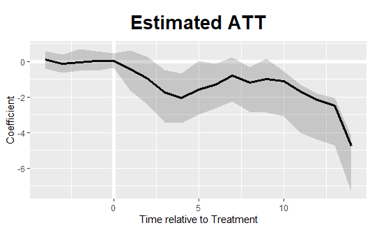

```r
plot(out_n2)#, ylim = c(-5000, 2000))
```

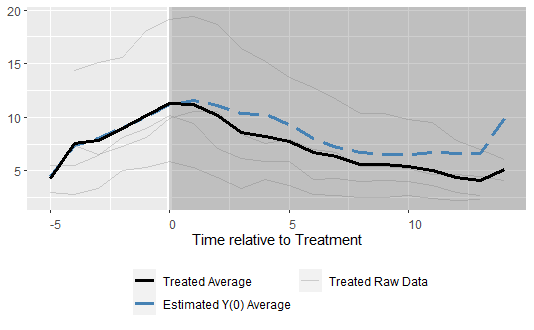

```r
# plot all data:
plot(out_n2, type = "counterfactual",
     raw = "all", main="") # Why the final dip?
```

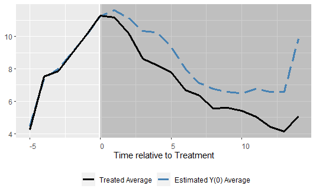

```r
plot(out_n2, type = "counterfactual",
     raw = "none", main="") # Why the final dip?
```

```
DE13 not in the treatment groupDE23 not in the treatment groupDEB3 not in the treatment groupDE50 not in the treatment groupDED5 not in the treatment group
```

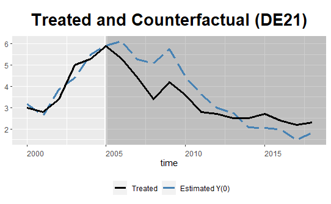

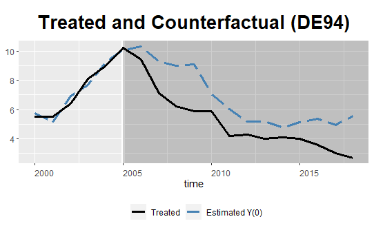

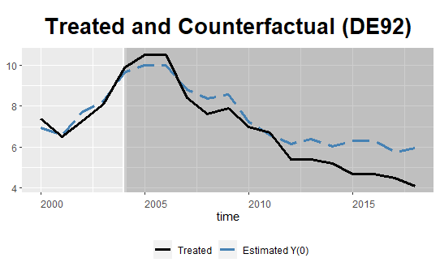

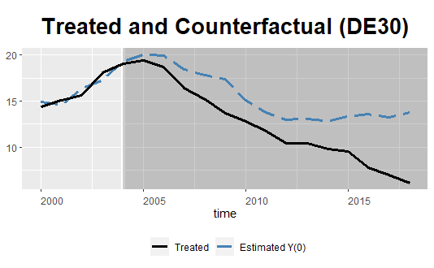

```r
for (i in n2_dta[n2_dta$treated_uz == TRUE, ]$geo %>% unique()){
  plot(out_n2, type = "counterfactual", id = i) # Berlin
}
```

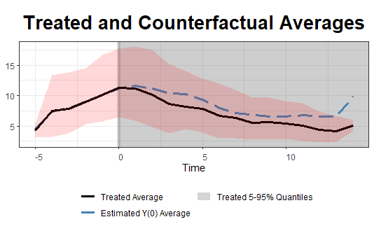

```r
#
# plot(out_n2, type = "counterfactual", id = "DE21") #
# plot(out_n2, type = "counterfactual", id = "DE13") # Freiburg
# plot(out_n2, type = "counterfactual", id = "DE50") # Bremen
# plot(out_n2, type = "counterfactual", id = "DE92") # Hannover
# plot(out_n2, type = "counterfactual", id = "DE60") # Bremen

# plot(out_n2, type = "raw", theme.bw = TRUE)

# We can also add two 5 to 95% quantile bands of the treated and control outcomes as references to make sure the estimated counterfactuals are not results of severe extrapolations.

# NOTE: THIS IS STRAGE, WHY ONLY BERLIN? I think because its the only treated
plot(out_n2, type = "counterfactual",
     raw = "band", xlab = "Time",
     # ylim = c(-5,35),
     theme.bw = TRUE)
```

```r
# plot(out_n2, type = "loadings")
```

```r
# out_n2$xi
```

```r
# Know the donor pool of each treated:

weights_result <- out_n2$wgt.implied %>%
  as_tibble(rownames = "NUTS_ID")


donor_pool <- nuts.sf.treated %>%
  filter(LEVL_CODE == 2) %>%
  left_join(weights_result) %>%
  filter(!is.na(DE30))

donor_pool %>% as.data.frame() %>%
  select(NUTS_ID, DE30, DE13)


leaflet() %>% addTiles() %>%
  addPolygons(data = donor_pool, weight = 0.5, color = "black",
              fillColor = ~colorQuantile("RdYlGn",
                      donor_pool$DE30)(donor_pool$DE30),
              popup = paste0(
                "<b>", donor_pool$NUTS_ID, "</b> <br/>",
                "<b> Weight Berlin </b>", donor_pool$DE30, "<br/>",
                "<b> Weight Freiburg </b>", donor_pool$DE13, "<br/>")
              )
```

### Try Gsynth N3

```r
# Prepare data for NUTS 2 synthetic control -> restrict controls
n3_dta <- main_dta %>%
  filter(treated_uz | contr_restr_50km) %>% # Controls are 50km away from cities that have applied a LEZ o similar mesure, probably have to bi limited to one treated only
  filter(nuts_level == 3)

# REVIEW DATA
n3_dta %>%
  select(geo, time, LEZ,
         Stage_1, is_inagurated,
         Announcment, is_announced,
         )  %>%
  filter(!is.na(Stage_1))

out_n3 <- gsynth(empl_rate_wpop ~ is_inagurated,
               data = n3_dta,
               index = c("geo","time"),
               na.rm = TRUE, # remove
               force = "two-way", # unit or time fixed effects or both?
               # CV = TRUE,
               # r = c(0, 4), # an integer specifying the number of factors. If CV = TRUE, the cross validation procedure will select the optimal number of factors from r to 5.
               se = TRUE,
               # EM = TRUE, # Gobillon and Magnac (takes a lot of time)
               # inference = "parametric",
               nboots = 100,  #500
               parallel = TRUE, cores = 5, # if do parallel and how many cores
               min.T0 = 7) # Has to be larger than r.max+1

n3_dta$is_inagurated %>% table()

out_n3 %>% print()
plot(out_n3)#, ylim = c(-5000, 2000))

# plot all data:
plot(out_n3, type = "counterfactual",
     raw = "all", main="") # Why the final dip?

plot(out_n3, type = "counterfactual",
     raw = "none", main="") # Why the final dip?

plot(out_n3, type = "counterfactual", id = "DE300") # Berlin

# plot(out_n2, type = "raw", theme.bw = TRUE)

# We can also add two 5 to 95% quantile bands of the treated and control outcomes as references to make sure the estimated counterfactuals are not results of severe extrapolations.

# NOTE: THIS IS STRAGE, WHY ONLY BERLIN? I think because its the only treated
plot(out_n3, type = "counterfactual",
     raw = "band", xlab = "Time",
     # ylim = c(-5,35),
     theme.bw = TRUE)

plot(out_n3, type = "loadings")

dim(out_n3$wgt.implied)
## [1] 38  9
sort(out_n3$wgt.implied[,8])
```

- A lot of removed treated units
- Factor loadings do not coincide, maybe some restriction of controls would be good.

```r
data(gsynth)

# ?gsynth
turnout
simdata

# out <- gsynth(Y ~ D + X1 + X2, data = simdata,
#               index = c("id","time"),
#               force = "two-way", CV = TRUE,
#               r = c(0, 5), se = TRUE,
#               inference = "parametric", nboots = 1000,
#               parallel = FALSE)
```

```r
# install.packages('gsynth', type = 'source')
library(gsynth)

out2 <- gsynth(gdp_eur_hab ~ treat_gz + gva_A + gva_B_E +
                 gva_F + gva_G_I + gva_J + gva_K + gva_L +
                 gva_M_N + gva_O_U,
               data = data_synth_c,
               index = c("geo","time"),
               force = "two-way",
               CV = TRUE,
               r = c(0, 4), # an integer specifying the number of factors. If CV = TRUE, the cross validation procedure will select the optimal number of factors from r to 5.
               se = TRUE,
               # EM = TRUE, # Gobillon and Magnac (takes a lot of time)
               inference = "parametric", nboots = 100,  #500
               parallel = TRUE,
               min.T0 = 6) # Has to be larger than r.max+1

# Idea: include countries/NUTS 2 regions and others as FE to control for heterogeneity?

# NOTE: I need to correct from assigning treatment by a point to assygn treatment by the area. If not, some NUTS3 in Paris and London will be counted as controls!
# They should eather be treated or cease to be controls [ ]
# !!!
```

```r
out_n2 %>% print()
out2$est.att
out2$est.avg
out2$est.beta
out2$Y.ct %>% as.data.frame() # pred counterfactuals for the treated units.
out2$Y.co %>% as.data.frame()
out2$eff %>% as.data.frame()  # Y - predicted Y(0);
out2$eff.cnt %>% as.data.frame() # Y - predicted Y(0); rearranged based on the timing of the treatment.

# Inspect results, how are the estimated tratement effects for all treated?

out2$eff.cnt %>% as.data.frame() %>% # Y - predicted Y(0);
  rownames_to_column(var = "year") %>%
  mutate(year = as.numeric(year)) %>%
  pivot_longer(-year, names_to = "geo",
               values_to = "y_minus_y0") %>%
  left_join(data) -> all_treat_effects

all_treat_effects %>%
  ggplot(aes(x = year, y = y_minus_y0)) +
  geom_line( aes(colour = nuts_name))
# Note: I need to see if this continues to happen for random pacebo treatments
all_treat_effects
```

*Questions:*

- What is the CV procedure of gsynth?
- What is the bootstraping procedure of gsynth?

```r
# out2$est.co$residuals %>% as.data.frame()
# plot(out2, ylim = c(-0.4, 0.02))
plot(out_n2)#, ylim = c(-5000, 2000))

plot(out_n2, type = "counterfactual",
     raw = "all", main="") # Why the final dip?

plot(out2, type = "counterfactual",
     raw = "none", main="") # Why the final dip?

plot(out_n2, type = "counterfactual", id = "DE30") # Berlin
# plot(out2, type = "counterfactual", id = "FR101") # Paris
# plot(out2, type = "counterfactual", id = "HU110") # Budapest
plot(out2, type = "counterfactual", id = "DE111") # Stuttgart
plot(out2, type = "counterfactual", id = "DE212") # München
# plot(out2, type = "counterfactual", id = "UKI32") #   Westminster (LDN)
# LONDON BOROUGHS! UKI31 - UKI45
# UKI31 Camden and City of London
# UKI32 Westminster
# UKI33 Kensington & Chelsea and Hammersmith & Fulham
# UKI34 Wandsworth
# UKI41 Hackney and Newham
# UKI42 Tower Hamlets
# UKI43 Haringey and Islington
# UKI44 Lewisham and Southwark
# UKI45 Lambeth
# UKI51 Bexley and Greenwich
# UKI52 Barking & Dagenham and Havering
# UKI53 Redbridge and Waltham Forest
# UKI54 Enfield

data_synth_c %>%
  filter(substr(geo, 1, 2) == "UK") %>%
  arrange(geo) %>%
  filter(geo == "UKI32")

# London (LEZ) initial date (2008) is WRONG, it is the ULEZ one (2019)
# The CCS was introduced in 2003, expansion on 2007
```

## Extras:

### Try to extract kmls (geographies of all LEZ):

*NOTE*: The files are encrypted, I need to deencrip them before. C#.

```r
# library(rgdal)
# belg_ghent = readOGR(dsn = "~/A - Estudios/LSE - Applied Social Data Science/Project/PM2.5/Data Europe/BelgienGent.kmls")
# ??readOGR
```

### Good info on spatial analysis:

https://mgimond.github.io/Spatial/uncertainty-in-census-data.html

### Fast and reliable computation of generalized synthetic controls (MSCMT package)

(look at Mendelay paper and to https://cran.r-project.org/web/packages/MSCMT/index.html)

### New methodologies (2019) on multiple timing and periods DiD:

https://andrewcbaker.netlify.com/2019/09/25/difference-in-differences-methodology/

### Abadie and L’Hour code for SCM with penalization for interpolation biases:

https://github.com/jlhourENSAE/regsynth

### RNN - based methods: Predict the synthetic control with NN:

https://ideas.repec.org/p/arx/papers/1712.03553.html

### “CausalInference” the Google made package to estimate Bayesian Structural Time Series Models:

https://google.github.io/CausalImpact/

### Critiques to synth methods with CV if done improperly:

- Look at Mendeley biblography on 04/2020

### Non-parametric Synth (Italian researcher - on STATA)

https://ideas.repec.org/c/boc/bocode/s458398.html https://www.sciencedirect.com/science/article/pii/S0165176519301788?entityID=https%3A%2F%2Flse.ac.uk%2Fidp&pes=vor

## Similar analysis with code and other methodologies: (to read and review)

https://andrewcbaker.netlify.com/2020/01/01/what-can-we-say-about-medical-marijuana-and-opioid-overdose-mortality/

## How much pollution comes from cars? (and other info from the EC):

https://ec.europa.eu/environment/air/cleaner_air/

## SUMMARY ST

How many LEZ in Europe?

```r
uar_dta$lez %>% sum(na.rm = TRUE)
```

```
[1] 273
```

## PLOTS:

### Small analysis of the application of LEZ zones in Germany:

```r
umweltzonen <- readRDS("data/umweltbundesamt/umweltzonen.rds")
# dbGetQuery(db, "SELECT * from umweltzonen")

um <- umweltzonen %>%
  mutate(Stage_1 = as.Date(Stage_1, "%d.%m.%Y"),
         Stage_2 = as.Date(Stage_2, "%d.%m.%Y"),
         Stage_3 = as.Date(Stage_3, "%d.%m.%Y"),
         Announcment = as.Date(Announcment)) %>%
  mutate(Announcment = if_else(is.na(Announcment),
                               Stage_1, Announcment)) %>%
  arrange(Stage_3) %>%
  arrange(Stage_2) %>%
  arrange(Stage_1) %>%
  arrange(Announcment) %>%
  mutate(num_id = 1:n())

all <- expand.grid(LEZ = um$LEZ,
                   year = seq(2006, 2018),
                   month = seq(01, 12),
                   # month = c("01", "02", "03", "04", "05", "06",
                   #          "07", "08", "09", "10", "11", "12"),
                   stringsAsFactors = FALSE)

panel_zones <- all %>%
  left_join(um) %>%
  mutate(date = as.POSIXct(paste0(year,"-", month, "-01" )),
         # LEZ = substr(LEZ, 1, 24),
         LEZ = sub(" *\\(.*", "", LEZ), # Everything until a "("
         # If i don't have the date of announcemnt I do as if there were none
         Announcment = if_else(is.na(Announcment), Stage_1, Announcment),

         status = case_when(
           date <= Announcment ~ 0, # not applied
           date <= Stage_1 ~ 1, # announced
           date <= Stage_2 ~ 2, # stage 1
           # If they don't have a stage 2 then they stayed in 1
           is.na(Stage_2) ~ 2,
           date <= Stage_3 ~ 3, #stage 2
           is.na(Stage_3) ~ 3,
           date > Stage_3 ~ 4, #stage 3
           # is.na(Announcment) ~ 0,
           # date < Stage_1
           TRUE ~ 0
         )
         # status = if_else(date < Announcment, 0, missing = 0,
         #                 if_else(date < Stage_1, 1,
         #                         if_else(date < Stage_2, 2,
         #                                 if_else(date < Stage_3, 3, 4,
         #                                         missing = 3))))
         # date_factor = paste0(year(date), "-", ifelse(
         #   month(date)<9, paste0("0", month(date)), month(date))),
         ) %>%
  arrange(Stage_3) %>%
  arrange(Stage_2) %>%
  arrange(Stage_1) %>%
  arrange(Announcment) %>%
  mutate(LEZ_number = paste0(LEZ, " - ", num_id)) %>%
  mutate(LEZ_factor = fct_inorder(LEZ_number)) %>%
  select(LEZ_number, date, status, year, month, LEZ_factor)
panel_zones %>% head()
```

|  | LEZ_number | date | status | year | month | LEZ_factor |
| --- | --- | --- | --- | --- | --- | --- |
| 1 | Heidelberg - 1 | 2006-01-01 | 0 | 2006 | 1 | Heidelberg - 1 |
| 2 | Heidelberg - 1 | 2007-01-01 | 1 | 2007 | 1 | Heidelberg - 1 |
| 3 | Heidelberg - 1 | 2008-01-01 | 1 | 2008 | 1 | Heidelberg - 1 |
| 4 | Heidelberg - 1 | 2009-01-01 | 1 | 2009 | 1 | Heidelberg - 1 |
| 5 | Heidelberg - 1 | 2010-01-01 | 1 | 2010 | 1 | Heidelberg - 1 |
| 6 | Heidelberg - 1 | 2011-01-01 | 2 | 2011 | 1 | Heidelberg - 1 |

```r
pv_timeline <- panelView(month ~ status, data = panel_zones,
          index = c("LEZ_factor", "date"),
          by.timing = TRUE,
          axis.lab.gap = c(23,0),
          # axis.lab = "time",
          background = "white",
          main = "",
          xlab = "", ylab = "",
          na.rm = FALSE,
          pre.post = TRUE,
          legend.labs = c("No LEZ applied", "LEZ announced",
                          "Only red, yellow or green sticker",
                          "Only yellow or green sticker",
                          "Only green stiker"),
          color = c("grey90", "grey60", "red1",
                    "yellow1", "green4")) +
  theme(legend.box.margin = margin(l = -5, unit = "cm"))
```

```
More than 2 treatment levels.
Specified colors in the order of: Treatment level: 0, Treatment level: 1, Treatment level: 2, Treatment level: 3, Treatment level: 4.
Specified labels in the order of: Treatment level: 0, Treatment level: 1, Treatment level: 2, Treatment level: 3, Treatment level: 4.
```

```r
png(filename = "images/LEZ application germany_3.png",
    width = 780, height = 1000, res = 100)
```

[figure not shown]

```r
pv_timeline +
  # # Black vertical segments (+.5 because the graph starts at 1)
  # geom_segment(x = 33.5, xend = 33.5, y = 2.5, yend = 31.5,
  #              size = 1.5) +
  geom_segment(x = 33.5+12, xend = 33.5+12, y = 31.5, yend = Inf,
               size = 1.5) +
  geom_segment(x = 12*12, xend = 12*12, y = 0.5, yend = 2.5,
               size = 1.5) +
  # geom_vline(xintercept = 33, size = 2) +
  # geom_vline(xintercept = 12*10, size = 1.5)

  # White shading areas
  # annotate("rect", xmin = 0, xmax=Inf, ymin=32.5, ymax=Inf,
  #                             alpha = 0.6, fill='white') +
  # annotate("rect", xmin = 0, xmax=Inf, ymin=0.5, ymax=4.5,
  #                             alpha = 0.6, fill='white') +
  # Black-shading year markers
  annotate("rect", xmin = 0.5, xmax=1.5, ymin=0.5, ymax=Inf,
           alpha = 0.2,
           fill = "black", size = 1.5) +
  annotate("rect", xmin = 12*1 + 0.5, xmax=12*1 + 1.5,
           ymin=0.5, ymax=Inf,
           alpha = 0.2,
           fill = "black", size = 1.5) +
  annotate("rect", xmin = 12*2 + 0.5, xmax=12*2 + 1.5,
           ymin=0.5, ymax=Inf,
           alpha = 0.2,
           fill = "black", size = 1.5) +
  annotate("rect", xmin = 12*3 + 0.5, xmax=12*3 + 1.5,
           ymin=0.5, ymax=Inf,
           alpha = 0.2,
           fill = "black", size = 1.5) +
  annotate("rect", xmin = 12*4 + 0.5, xmax=12*4 + 1.5,
           ymin=0.5, ymax=Inf,
           alpha = 0.2,
           fill = "black", size = 1.5) +
  annotate("rect", xmin = 12*5 + 0.5, xmax=12*5 + 1.5,
           ymin=0.5, ymax=Inf,
           alpha = 0.2,
           fill = "black", size = 1.5) +
  annotate("rect", xmin = 12*6 + 0.5, xmax=12*6 + 1.5,
           ymin=0.5, ymax=Inf,
           alpha = 0.2,
           fill = "black", size = 1.5) +
  annotate("rect", xmin = 12*7 + 0.5, xmax=12*7 + 1.5,
           ymin=0.5, ymax=Inf,
           alpha = 0.2,
           fill = "black", size = 1.5) +
  annotate("rect", xmin = 12*8 + 0.5, xmax=12*8 + 1.5,
           ymin=0.5, ymax=Inf,
           alpha = 0.2,
           fill = "black", size = 1.5) +
  annotate("rect", xmin = 12*9 + 0.5, xmax=12*9 + 1.5,
           ymin=0.5, ymax=Inf,
           alpha = 0.2,
           fill = "black", size = 1.5) +
    annotate("rect", xmin = 12*10 + 0.5, xmax=12*10 + 1.5,
           ymin=0.5, ymax=Inf,
           alpha = 0.2,
           fill = "black", size = 1.5) +
    annotate("rect", xmin = 12*11 + 0.5, xmax=12*11 + 1.5,
           ymin=0.5, ymax=Inf,
           alpha = 0.2,
           fill = "black", size = 1.5) +
    annotate("rect", xmin = 12*12 + 0.5, xmax=12*12 + 1.5,
           ymin=0.5, ymax=Inf,
           alpha = 0.2,
           fill = "black", size = 1.5) +
  # red square
  annotate("rect", xmin = 1, xmax=Inf, ymin=2.5, ymax=31.5,
           alpha = 0.6, color = "red",
           fill = NA, size = 1.5) +
  # Text
  geom_curve(aes(x = 8*12-4, y = 42, xend = 33.5+12, yend = 34),
             colour = "black",
             size=1,
             curvature = -0.2,
             arrow = arrow(length = unit(0.03, "npc"))
             ) +
  geom_label(aes(x = 8*12-4, y = 42,
                 label = "End of Scrappage\n Program"),
             hjust = 0,
             vjust = 0.5,
             colour = "black",
             fill = "white",
             # label.size = NA,
             # family="Helvetica",
             size = 5)

dev.off()
```

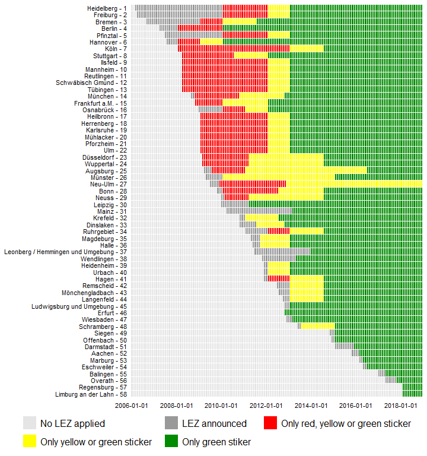

```r
# png(filename = "images/LEZ application germany_clean.png",
#     width = 780, height = 1000, res = 100)
# pv_timeline
# dev.off()

# devtools::install_github('xuyiqing/panelView')
# RColorBrewer::brewer.pal.info
pv_timeline
```

> NOTE! I NEED TO FIND THE DATE OF ANOUNCEMT OF THE MISSING LEZ!

(Image saved in png file)

Simple Version:

```
More than 2 treatment levels.
Specified colors in the order of: Treatment level: 0, Treatment level: 1, Treatment level: 2, Treatment level: 3.
Specified labels in the order of: Treatment level: 0, Treatment level: 1, Treatment level: 2, Treatment level: 3.
```

[figure not shown]

```r
# png(filename = "LEZ application germany.png",
#     width = 750, height = 1000, res = 100)
panelView(month ~ status, data = panel_zones,
          index = c("LEZ_factor", "date"),
          by.timing = TRUE,
          axis.lab.gap = c(23,0),
          # axis.lab = "time",
          background = "white",
          main = "",
          xlab = "", ylab = "", pre.post = TRUE,
          legend.labs = c("No LEZ applied",
                          "Only red, yellow or green sticker",
                          "Only yellow or green sticker", "Only green stiker"),
          color = c("grey90", "red1", "yellow1", "green4"))
```

```r
# dev.off()

# devtools::install_github('xuyiqing/panelView')
# RColorBrewer::brewer.pal.info
```

(Image saved in png file)

### Map of cities

```r
# Get data on cities with LEZ
umweltzonen_map <- um %>%
  mutate(in_sample =
           ifelse(year_announced < 2009 | is.na(year_announced),
                            "Excluded", "Included"))

# umweltzonen
#
# main_dta %>%
#   filter(LEZ == "Berlin") %>%
#   select(LEZ, gdp_mio_eur)


# Merge it with cities' NUTS characteristics
umweltzonen_map <-  main_dta %>%
  filter(treated_uz == TRUE) %>%
  select(LEZ, gdp_mio_eur) %>%
  group_by(LEZ) %>%
  summarise_all(function(x){mean(x, na.rm =  TRUE)}) %>%
  right_join(umweltzonen_map) %>%
  st_as_sf()
# Get coodinates and characteristics of 3 "control" regions

nuts_time %>%
  filter(geo %in% c("DE402", "DED41", "DEF03")) %>%
  select(geo, gdp_mio_eur) %>%
  group_by(geo) %>%
  summarise_all(function(x){mean(x, na.rm =  TRUE)})
```

| geo | gdp_mio_eur |
| --- | --- |
| DE402 | 2865.472 |
| DED41 | 6968.656 |
| DEF03 | 6670.629 |

```r
temp <- data.frame(LEZ = c("Lübeck", "Cottbus", "Chemnitz"),
                   in_sample = rep("Control", 3),
                   gdp_mio_eur = c(2865, 6969, 6671),
                   lat = c(53.85678, 51.760325, 50.835651),
                   lon = c(10.67413, 14.325153, 12.929591)
                   )

temp_sf <- temp %>%
  st_as_sf(coords = c("lon", "lat"),
           crs = "+proj=longlat +datum=WGS84 +no_defs")

umweltzonen_pro <- umweltzonen_map %>%
  select(LEZ, in_sample, gdp_mio_eur) %>%
  rbind(temp_sf)

umweltzonen_pro
```

```
Simple feature collection with 61 features and 3 fields
geometry type:  POINT
dimension:      XY
bbox:           xmin: 6.096469 ymin: 47.98732 xmax: 14.32515 ymax: 53.85678
CRS:            +proj=longlat +datum=WGS84 +no_defs
```

| LEZ | in_sample | gdp_mio_eur | geometry |
| --- | --- | --- | --- |
| Aachen | Included | 16474.129 |  |
| Augsburg | Included | 11442.763 |  |
| Balingen | Included | 5257.429 |  |
| Berlin | Excluded | 103545.762 |  |
| Bonn | Included | 20309.952 |  |
| Bremen | Excluded | 25470.972 |  |
| Darmstadt | Included | 8970.424 |  |
| Dinslaken | Included | 10441.571 |  |
| Düsseldorf | Excluded | 41478.822 |  |
| Erfurt | Included | 28447.618 |  |

[output cut: 51 more lines]

```r
separated_coord <- umweltzonen_map %>%
    mutate(lat = unlist(map(umweltzonen_map$geometry,1)),
           long = unlist(map(umweltzonen_map$geometry,2)))

separated_coord_control <- temp_sf %>%
  filter(in_sample == "Control") %>%
    mutate(lat = unlist(map(temp$geometry,1)),
           long = unlist(map(temp$geometry,2)))

# Get basemap for Germany

# library("rnaturalearth")
# library("rnaturalearthdata")
#
# germany <- ne_countries(scale = "medium",
#                       country = "germany",
#                       returnclass = "sf")

germany2 <- nuts_treated %>%
  filter(country == "DE") %>%
  st_combine() %>%
  st_union()
```

[figure not shown]

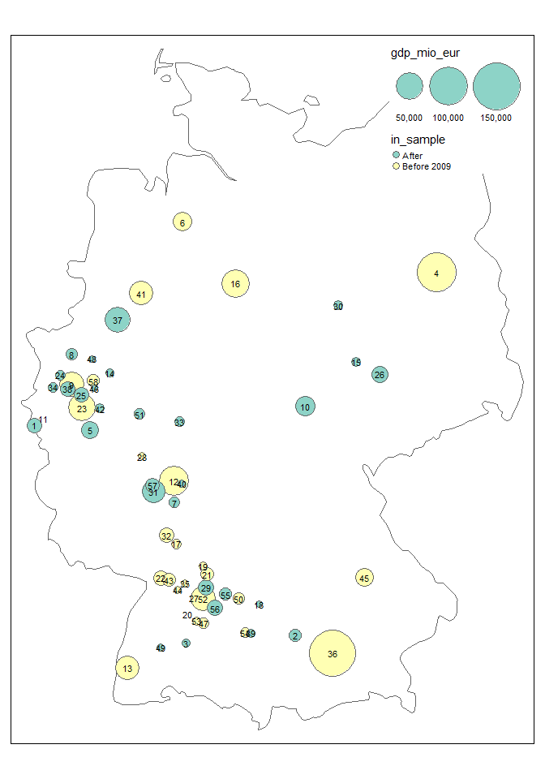

```r
tm_shape(germany) +
    tm_borders() +
tm_shape(umweltzonen) +
    tm_symbols(col = "in_sample",
               size = "gdp_mio_eur",
               scale = 4) +
    tm_text("num_id", size = 0.7,
            # auto.placement = TRUE
            ) +
  tm_layout(legend.bg.color = "white")
```

```r
tm_legend(show = FALSE)
```

```
$tm_layout
$tm_layout$legend.show
[1] FALSE

$tm_layout$style
[1] NA


attr(,"class")
[1] "tm"
```

```r
umweltzonen
```

```
Simple feature collection with 58 features and 16 fields
geometry type:  POINT
dimension:      XY
bbox:           xmin: 6.096469 ymin: 47.98732 xmax: 13.42475 ymax: 53.07962
CRS:            +proj=longlat +datum=WGS84 +no_defs
```

| LEZ | gdp_mio_eur | State | simple_LEZ | Status | Stage_1 | Stage_2 | Stage_3 | Announcment | year_stage1 | year_stage2 | year_stage3 | date_announced | year_announced | geometry | in_sample | num_id |
| --- | --- | --- | --- | --- | --- | --- | --- | --- | --- | --- | --- | --- | --- | --- | --- | --- |
| Aachen | 16474.129 | Nordrhein-Westfalen | Aachen | Stufe 3 | 01.02.2016 | 01.02.2016 | 01.02.2016 | 2015-10-20 | 2016 | 2016 | 2016 | 2015-10-20 | 2015 |  | After | 1 |
| Augsburg | 11442.763 | Bayern | Augsburg | Stufe 3 | 01.07.2009 | 01.01.2011 | 01.06.2016 | 2009-03-01 | 2009 | 2011 | 2016 | 2009-03-01 | 2009 |  | After | 2 |
| Balingen | 5257.429 | Baden-Württemberg | Balingen | Stufe 3 | 01.04.2017 | 01.04.2017 | 01.04.2017 | 2016-12-01 | 2017 | 2017 | 2017 | 2016-12-01 | 2016 |  | After | 3 |
| Berlin | 103545.762 | Berlin | Berlin | Stufe 3 | 01.01.2008 | 01.01.2010 | 01.01.2010 | 2007-03-20 | 2008 | 2010 | 2010 | 2007-03-20 | 2007 |  | Before 2009 | 4 |
| Bonn | 20309.952 | Nordrhein-Westfalen | Bonn | Stufe 3 | 01.01.2010 | 01.07.2012 | 01.07.2014 | 2009-10-01 | 2010 | 2012 | 2014 | 2009-10-01 | 2009 |  | After | 5 |
| Bremen | 25470.972 | Bremen | Bremen Mitte | Stufe 3 | 01.01.2009 | 01.01.2010 | 01.07.2011 | 2006-08-01 | 2009 | 2010 | 2011 | 2006-08-01 | 2006 |  | Before 2009 | 6 |
| Darmstadt | 8970.424 | Hessen | Darmstadt | Stufe 3 | 01.11.2015 | 01.11.2015 | 01.11.2015 | 2015-01-06 | 2015 | 2015 | 2015 | 2015-01-06 | 2015 |  | After | 7 |
| Dinslaken | 10441.571 | Nordrhein-Westfalen | Dinslaken | Stufe 3 | 01.07.2011 | 01.07.2011 | 01.10.2012 | 2010-10-08 | 2011 | 2011 | 2012 | 2010-10-08 | 2010 |  | After | 8 |
| Düsseldorf | 41478.822 | Nordrhein-Westfalen | Düsseldorf | Stufe 3 | 15.02.2009 | 01.03.2011 | 01.07.2014 | NA | 2009 | 2011 | 2014 |  | NA |  | Before 2009 | 9 |
| Erfurt | 28447.618 | Thüringen | Erfurt | Stufe 3 | 01.10.2012 | 01.10.2012 | 01.10.2012 | 2012-10-10 | 2012 | 2012 | 2012 | 2012-10-10 | 2012 |  | After | 10 |

[output cut: 48 more lines]